# Race/Ethnicity Exposure - County

Author

Aaron R. Williams, Vincent Pancini, and Manu Alcalá Kovalski

Published

March 3, 2025

# Racial/ethnic Exposure

This metric measures the exposure of a given race/ethnicity group to other race/ethnicity groups. The metric is calculated at the Census tract level and then aggregated to the county level. We are interested in Hispanic, non-Hispanic Black, non-Hispanic white, and Other Races and Ethnicities.

1. On average, people who are Hispanic live in neighborhoods that are X% non-Hispanic.
2. On average, people who are non-Hispanic Black live in neighborhoods that are X% non-non-Hispanic Black.
3. On average, people who are non-Hispanic white live in neighborhoods that are X% non-non-Hispanic white.
4. On average, people who are Other Races and Ethnicities live in neighborhoods that are x% non-Other Races and Ethnicities.

**Process:**

1. Pull all non-overlapping race/ethnicity groups needed to create Hispanic, non-Hispanic Black, non-Hispanic white, and Other Races and Ethnicities.
2. Collapse the detailed groups to the four groups of interest.
3. Calculate the share of a county’s racial/ethnic group in each tract.
4. Calculate exposure to other racial/ethnic groups:
   - Calculate Hispanic exposure to other three groups.
   - Calculate non-Hispanic Black exposure to other three groups.
   - Calculate non-Hispanic white exposure to other three groups.
   - Calculate Other Races and Ethnicities exposure to other three groups.
5. Validation
6. Add data quality flags
7. Save the data

```r
options(scipen = 999)

library(tidyverse)
library(censusapi)
library(urbnthemes)
library(reactable)
library(tidylog)

set_urbn_defaults(style = "print")

# source(here::here("06_neighborhoods", "R", "census_api_key.R"))
source(here::here("06_neighborhoods", "R", "get_vars.R"))
source(here::here("functions", "testing", "evaluate_final_data.R"))
```

## ACS 5-Year Estimates

### 1. Pull all non-overlapping race/enthnicity groups needed to create Hispanic, non-Hispanic Black, non-Hispanic white, and Other Races and Ethnicities.

The American Community Survey reports detailed race and ethnicity by the following table.

[figure not shown]

```r
knitr::include_graphics(here::here("06_neighborhoods", "www", "images", "race-ethnicity.png"))
```

We pull all of the race/ethnicity counts using `library(censusapi)`. **Note:** This will require a [Census API key](https://api.census.gov/data/key_signup.html). Add the key to `census_api_key-template.R` and then delete then delete “template”. It is sourced above.

The variable codes for population by race/ethnicity are different for different years. Therefore, we construct a tribble with the variable-year combinations

```r
# Tribble with year-specific ACS codes and corresponding labels
variable_mapping <- tribble(
  ~year, ~code, ~label,
  # 2016 Codes
  2016, "DP05_0066E", "hispanic",
  2016, "DP05_0066M", "hispanic_moe",
  2016, "DP05_0072E", "white_nh",
  2016, "DP05_0072M", "white_nh_moe",
  2016, "DP05_0073E", "black_nh",
  2016, "DP05_0073M", "black_nh_moe",
  2016, "DP05_0074E", "aian_nh",
  2016, "DP05_0074M", "aian_nh_moe",
  2016, "DP05_0075E", "asian_nh",
  2016, "DP05_0075M", "asian_nh_moe",
  2016, "DP05_0076E", "nhpi_nh",
  2016, "DP05_0076M", "nhpi_nh_moe",
  2016, "DP05_0077E", "census_other_nh",
  2016, "DP05_0077M", "census_other_nh_moe",
  2016, "DP05_0078E", "two_or_more_nh",
  2016, "DP05_0078M", "two_or_more_nh_moe",
  2018, "DP05_0071E", "hispanic",
  2018, "DP05_0071M", "hispanic_moe",
  2018, "DP05_0077E", "white_nh",
  2018, "DP05_0077M", "white_nh_moe",
  2018, "DP05_0078E", "black_nh",
  2018, "DP05_0078M", "black_nh_moe",
  2018, "DP05_0079E", "aian_nh",
  2018, "DP05_0079M", "aian_nh_moe",
  2018, "DP05_0080E", "asian_nh",
  2018, "DP05_0080M", "asian_nh_moe",
  2018, "DP05_0081E", "nhpi_nh",
  2018, "DP05_0081M", "nhpi_nh_moe",
  2018, "DP05_0082E", "census_other_nh",
  2018, "DP05_0082M", "census_other_nh_moe",
  2018, "DP05_0083E", "two_or_more_nh",
  2018, "DP05_0083M", "two_or_more_nh_moe",
  2021, "DP05_0071E", "hispanic",
  2021, "DP05_0071M", "hispanic_moe",
  2021, "DP05_0077E", "white_nh",
  2021, "DP05_0077M", "white_nh_moe",
  2021, "DP05_0078E", "black_nh",
  2021, "DP05_0078M", "black_nh_moe",
  2021, "DP05_0079E", "aian_nh",
  2021, "DP05_0079M", "aian_nh_moe",
  2021, "DP05_0080E", "asian_nh",
  2021, "DP05_0080M", "asian_nh_moe",
  2021, "DP05_0081E", "nhpi_nh",
  2021, "DP05_0081M", "nhpi_nh_moe",
  2021, "DP05_0082E", "census_other_nh",
  2021, "DP05_0082M", "census_other_nh_moe",
  2021, "DP05_0083E", "two_or_more_nh",
  2021, "DP05_0083M", "two_or_more_nh_moe",
  2023, "DP05_0076E", "hispanic",
  2023, "DP05_0076M", "hispanic_moe",
  2023, "DP05_0082E", "white_nh",
  2023, "DP05_0082M", "white_nh_moe",
  2023, "DP05_0083E", "black_nh",
  2023, "DP05_0083M", "black_nh_moe",
  2023, "DP05_0084E", "aian_nh",
  2023, "DP05_0084M", "aian_nh_moe",
  2023, "DP05_0085E", "asian_nh",
  2023, "DP05_0085M", "asian_nh_moe",
  2023, "DP05_0086E", "nhpi_nh",
  2023, "DP05_0086M", "nhpi_nh_moe",
  2023, "DP05_0087E", "census_other_nh",
  2023, "DP05_0087M", "census_other_nh_moe",
  2023, "DP05_0088E", "two_or_more_nh",
  2023, "DP05_0088M", "two_or_more_nh_moe"
)

pull_and_rename <- function(year) {
  vars <- variable_mapping %>%
    filter(year == {{ year }}) %>%
    pull(code)

  tracts_raw <-
    get_vars(
      year = year, vars = vars,
      geography = "tract", source = "acs/acs5/profile"
    ) |>
    mutate(year = {{ year }})


  rename_lookup <- variable_mapping %>%
    filter(year == {{ year }}) %>%
    select(code, label) %>%
    distinct() %>%
    deframe()

  # Rename columns using the lookup
  tracts <- tracts_raw %>%
    rename_with(~ rename_lookup[.x], .cols = names(rename_lookup)) |>
    rename(people = B01003_001E) # from get_vars()


  return(tracts)
}

years <- c(2016, 2018, 2021, 2023)

if(!file.exists(here::here("06_neighborhoods/race-ethnicity-exposure/data/tracts.csv"))){
  tracts_raw <- map(years, ~ pull_and_rename(.x)) |>
  list_rbind() |>
  relocate(year, .before = everything())

  if(!dir.exists(here::here("06_neighborhoods/race-ethnicity-exposure/data"))) {
  dir.create(here::here("06_neighborhoods/race-ethnicity-exposure/data"))
}
  write_csv(tracts_raw, here("06_neighborhoods/race-ethnicity-exposure/data/tracts.csv"))
}
```

Since the code chunk above takes roughly 30 minutes to run, we export and import the data back

```r
tracts_raw <- read_csv(here("06_neighborhoods/race-ethnicity-exposure/data/tracts.csv"))
```

Certain estimates are controlled. The margins of errors for these estimates will appear as `-555555555` but [can be treated as zero](https://www.census.gov/content/dam/Census/programs-surveys/acs/guidance/training-presentations/20180418_MOE_Webinar_Transcript.pdf). [Here are all of the special codes.](https://www.census.gov/data/developers/data-sets/acs-1year/data-notes.html)

```r
tracts <- tracts_raw %>%
  mutate(hispanic_moe = if_else(hispanic_moe == -555555555, 0, hispanic_moe))
```

We calculate the coefficients of variation for each variable.

```r
tracts_cv <- tracts %>%
  mutate(
    hispanic_cv = (hispanic_moe / 1.645) / hispanic,
    black_nh_cv = (black_nh_moe / 1.645) / black_nh,
    white_nh_cv = (white_nh_moe / 1.645) / white_nh,
    aian_nh_cv = (aian_nh_moe / 1.645) / aian_nh,
    nhpi_nh_cv = (nhpi_nh_moe / 1.645) / nhpi_nh,
    census_other_nh_cv = (census_other_nh_moe / 1.645) / census_other_nh,
    two_or_more_nh_cv = (two_or_more_nh_moe / 1.645) / two_or_more_nh
  )
```

```r
tracts_cv %>%
  summarize(
    hispanic = mean(hispanic_cv >= 0.4),
    black_nh = mean(black_nh_cv >= 0.4),
    white_nh = mean(white_nh_cv >= 0.4),
    aian_nh = mean(aian_nh_cv >= 0.4),
    nhpi_nh = mean(nhpi_nh_cv >= 0.4),
    census_other_nh = mean(census_other_nh_cv >= 0.4),
    two_or_more_nh = mean(two_or_more_nh_cv >= 0.4),
    .by = year
  )
```

```
# A tibble: 4 × 8
   year hispanic black_nh white_nh aian_nh nhpi_nh census_other_nh
  <dbl>    <dbl>    <dbl>    <dbl>   <dbl>   <dbl>           <dbl>
1  2016    0.427    0.553   0.0560   0.969   0.996           0.998
2  2018    0.412    0.553   0.0563   0.970   0.996           0.998
3  2021    0.485    0.635   0.0746   0.976   0.997           0.998
4  2023    0.452    0.629   0.0746   0.976   0.997           0.998
# ℹ 1 more variable: two_or_more_nh <dbl>
```

Other Races and Ethnicities includes Non-Hispanic American Indian and Alaska Native alone (`aian_nh`), Non-Hispanic Asian alone (`asian_nh`), non-Hispanic Native Hawaiian and Other Pacific Island alone (`nhpi_nh`), non-Hispanic other (`other_nh`), and non-Hispanic two or more (`two_or_more_nh`).

```r
tracts <- tracts %>%
  mutate(
    other_nh =
      aian_nh +
        asian_nh +
        nhpi_nh +
        census_other_nh +
        two_or_more_nh,
    other_nh_moe =
      sqrt(
        aian_nh_moe^2 +
          asian_nh_moe^2 +
          nhpi_nh_moe^2 +
          census_other_nh_moe^2 +
          two_or_more_nh_moe^2
      )
  )
```

[This Census presentation](https://www.census.gov/content/dam/Census/programs-surveys/acs/guidance/training-presentations/20180418_MOE_Webinar_Transcript.pdf) recommends using the maximum margin of error when aggregating multiple zero estimates.

> One way this approximation can differ from the actual MOE is if you were aggregating multiple zero estimates. In this case, the approximate MOE could diverge from the actual margin of error. And so the - our recommendation is to only include one zero estimate margin of error and include the largest one.

```r
# pivot the point estimates
values <- tracts %>%
  select(
    year,
    state,
    county,
    tract,
    aian_nh,
    asian_nh,
    nhpi_nh,
    census_other_nh,
    two_or_more_nh
  ) %>%
  pivot_longer(c(-year, -state, -county, -tract), names_to = "group", values_to = "value")

# pivot the margins of error
moes <- tracts %>%
  select(
    year,
    state,
    county,
    tract,
    aian_nh_moe,
    asian_nh_moe,
    nhpi_nh_moe,
    census_other_nh_moe,
    two_or_more_nh_moe
  ) %>%
  pivot_longer(c(-year, -state, -county, -tract), names_to = "group", values_to = "moe") %>%
  mutate(group = str_replace(group, "_moe", ""))

# combine the point estimates and margins of error
other_moe <- left_join(values, moes, by = c("year", "state", "county", "tract", "group"))

rm(moes, values)

# keep MOE for non-zero estimates and keep the largest MOE for zero estimates
# NOTE: we're only keeping the largest MOE once
other_moe <- other_moe %>%
  group_by(year, state, county, tract) %>%
  mutate(moe_rank = row_number(desc(moe))) %>%
  mutate(moe_rank = if_else(value == 0, moe_rank, 5L)) %>%
  mutate(moe_rank = ifelse(moe_rank == min(moe_rank), moe_rank, 0L)) %>%
  filter(value != 0 | moe_rank != 0) %>%
  select(-moe_rank)

# combine the margins of error
other_moe <- other_moe %>%
  summarize(other_nh_moe_reduced = sqrt(sum(moe^2))) %>%
  ungroup()

# append to the original data set
tracts <- left_join(tracts, other_moe, by = c("year", "state", "county", "tract"))
```

We convert margins of error to standard errors using 1.645 as the critical value ([page 3](https://www2.census.gov/programs-surveys/acs/tech_docs/accuracy/2018_ACS_Accuracy_Document_Worked_Examples.pdf?))

```r
tracts <- tracts %>%
  mutate(
    hispanic_se = hispanic_moe / 1.645,
    black_nh_se = black_nh_moe / 1.645,
    other_nh_se = other_nh_moe / 1.645,
    white_nh_se = white_nh_moe / 1.645,
    other_nh_se_reduced = other_nh_moe_reduced / 1.645
  )
```

```r
tracts <- tracts %>%
  select(
    year,
    state,
    county,
    tract,
    people,
    hispanic,
    black_nh,
    other_nh,
    white_nh,
    hispanic_se,
    black_nh_se,
    other_nh_se,
    white_nh_se,
    other_nh_se_reduced,
    hispanic_moe,
    black_nh_moe,
    other_nh_moe,
    other_nh_moe_reduced,
    white_nh_moe
  )
```

**Check:** Do the pulled race/ethnicity counts sum to the tract populations?

```r
stopifnot(
  tracts %>%
    mutate(people2 = hispanic + black_nh + other_nh + white_nh) %>%
    filter(people != people2) %>%
    nrow() == 0
)
```

After combining the detailed race/ethnicity groups into Other Races and Ethnicities, we expect the share of Census tracts with coefficients of variation greater than 0.4 to decline. A large share of the Other Races and Ethnicities have coefficients of variation greater than 0.4. The first value uses the CV without adjustment and the second value uses the CV with adjustment.

```r
tracts %>%
  summarize(
    mean((other_nh_se / other_nh) > 0.4),
    mean((other_nh_se_reduced / other_nh) > 0.4),
    .by = year
  )
```

```
# A tibble: 4 × 3
   year `mean((other_nh_se/other_nh) > 0.4)` mean((other_nh_se_reduced/other_n…¹
  <dbl>                                <dbl>                               <dbl>
1  2016                                0.494                               0.482
2  2018                                0.483                               0.471
3  2021                                0.528                               0.518
4  2023                                0.456                               0.444
# ℹ abbreviated name: ¹`mean((other_nh_se_reduced/other_nh) > 0.4)`
```

Let’s keep the adjusted margin of error for Other Races and Ethnicities.

```r
tracts <- tracts %>%
  select(-other_nh_moe, -other_nh_se) %>%
  rename(
    other_nh_se = other_nh_se_reduced,
    other_nh_moe = other_nh_moe_reduced
  )
```

Let’s plot the relationship between the margins of error and the number of people who identify as the four different race/ethnicity groups in each county. Points that appear above and to the left of the black line have coefficients of variation greater than 0.4.

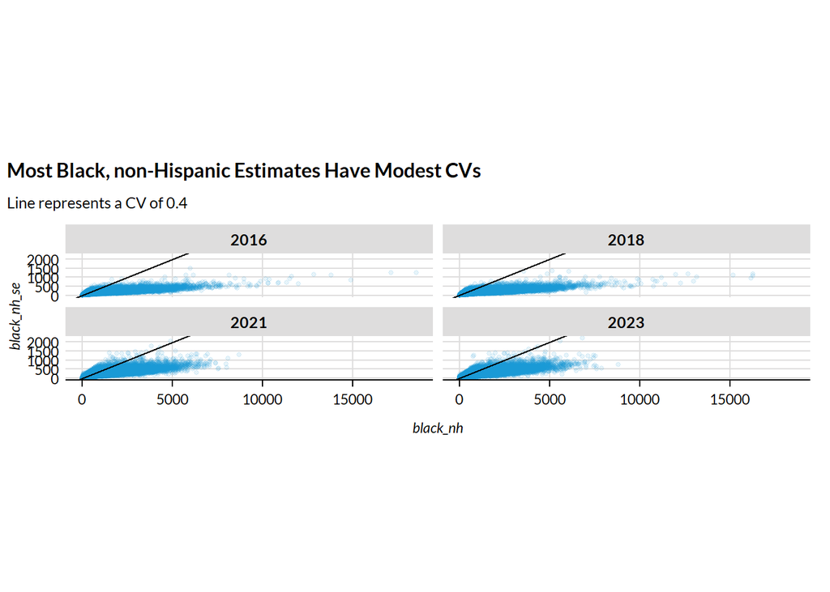

```r
tracts %>%
  ggplot(aes(black_nh, black_nh_se)) +
  geom_point(alpha = 0.1, size = 1) +
  geom_abline(aes(slope = 0.4, intercept = 0)) +
  labs(
    title = "Most Black, non-Hispanic Estimates Have Modest CVs",
    subtitle = "Line represents a CV of 0.4"
  ) +
  coord_equal() +
  scatter_grid() +
  facet_wrap(. ~ year)
```

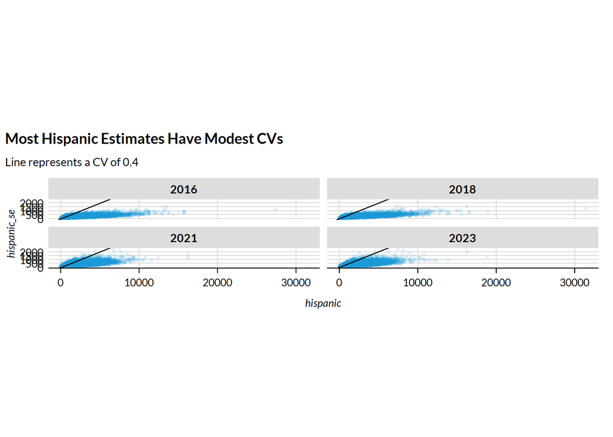

```r
tracts %>%
  ggplot(aes(hispanic, hispanic_se)) +
  geom_point(alpha = 0.1, size = 1) +
  geom_abline(aes(slope = 0.4, intercept = 0)) +
  labs(
    title = "Most Hispanic Estimates Have Modest CVs",
    subtitle = "Line represents a CV of 0.4"
  ) +
  coord_equal() +
  scatter_grid() +
  facet_wrap(. ~ year)
```

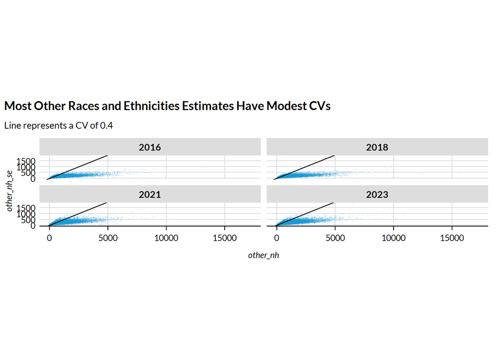

```r
tracts %>%
  ggplot(aes(other_nh, other_nh_se)) +
  geom_point(alpha = 0.1, size = 0.2) +
  geom_abline(aes(slope = 0.4, intercept = 0)) +
  labs(
    title = "Most Other Races and Ethnicities Estimates Have Modest CVs",
    subtitle = "Line represents a CV of 0.4"
  ) +
  coord_equal() +
  scatter_grid() +
  facet_wrap(. ~ year)
```

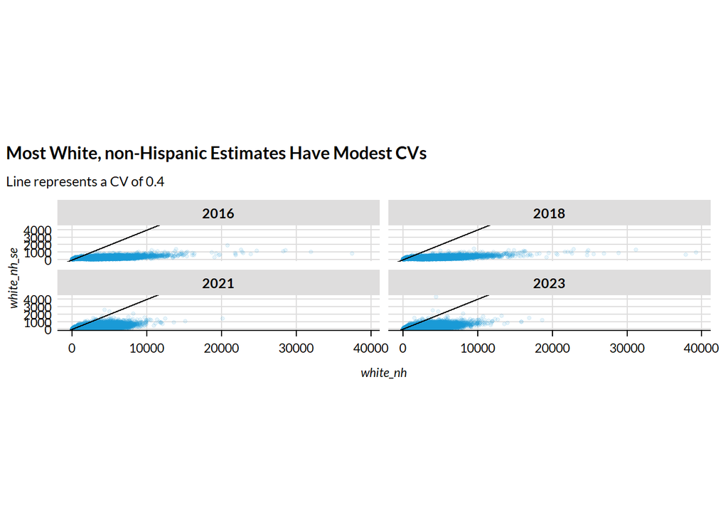

```r
tracts %>%
  ggplot(aes(white_nh, white_nh_se)) +
  geom_point(alpha = 0.1, size = 1) +
  geom_abline(aes(slope = 0.4, intercept = 0)) +
  labs(
    title = "Most White, non-Hispanic Estimates Have Modest CVs",
    subtitle = "Line represents a CV of 0.4"
  ) +
  coord_equal() +
  scatter_grid() +
  facet_wrap(. ~ year)
```

### 3. Calculate the share of a county’s racial/ethnic group in each tract

```r
indices <- tracts %>%
  mutate(
    share_of_black_nh = black_nh / sum(black_nh),
    share_of_hispanic = hispanic / sum(hispanic),
    share_of_other_nh = other_nh / sum(other_nh),
    share_of_white_nh = white_nh / sum(white_nh),
    .by = c(year, state, county)
  )
```

**Check:** Do the shares in each tract sum to one in a county?

```r
stopifnot(
  indices %>%
    group_by(year, state, county) %>%
    summarize(
      share_of_black_nh = sum(share_of_black_nh),
      share_of_hispanic = sum(share_of_hispanic),
      share_of_other_nh = sum(share_of_other_nh),
      share_of_white_nh = sum(share_of_white_nh)
    ) %>%
    filter(!near(share_of_white_nh, 1) |
      !near(share_of_black_nh, 1) |
      !near(share_of_hispanic, 1) |
      !near(share_of_other_nh, 1)) %>%
    nrow() == 0
)
```

### 4. Calculate exposure to other racial/ethnic groups

- Calculate non-Hispanic Black exposure to the other groups.
- Calculate Hispanic exposure to the other groups.
- Calculate non-Hispanic white exposure to the other groups.
- Calculate Other Races and Ethnicities exposure to the other groups.

> Focusing just on whites for simplicity, we want to compute the average share of neighbors who are non-white. Thus for each census tract in a county, we need to know the percentage non-white.

Calculate the complement to each race/ethnic group of interest.

```r
indices <- indices %>%
  mutate(
    non_white_nh = (hispanic + black_nh + other_nh) / people,
    non_black_nh = (hispanic + white_nh + other_nh) / people,
    non_hispanic = (white_nh + black_nh + other_nh) / people,
    non_other_nh = (hispanic + white_nh + black_nh) / people
  )
```

> We would then take the weighted average across tracts with the weight being the percentage of a county’s whites living in each tract. So in a county with only 2 tracts, one tract has 80 whites and only 10 percent of that residents are non-white and in the second tract there are 20 white residents but 50% of the tract is non-white, the white to non-white index would be 0.8 * 0.1 + 0.2 * 0.5 = 0.18. In other words the average white resident lives in a neighborhood in which 18% of his neighbors are non-white

We find the weighted average at the county level of exposure to other race/ethnicity groups weighted by the share of the race/ethnicity group living in each tract. In other words, the 0.1 and 0.5 are `non_white_nh` and the 0.8 and 0.2 are `share_of_white_nh`.

```r
county_data <- indices %>%
  summarize(
    tracts = n(),
    people = sum(people),
    # counts
    black_nh = sum(black_nh),
    hispanic = sum(hispanic),
    other_nh = sum(other_nh),
    white_nh = sum(white_nh),
    # standard errors
    black_nh_se = sqrt(sum(black_nh_moe^2)) / 1.645,
    hispanic_se = sqrt(sum(hispanic_moe^2)) / 1.645,
    other_nh_se = sqrt(sum(other_nh_moe^2)) / 1.645,
    white_nh_se = sqrt(sum(white_nh_moe^2)) / 1.645,
    # exposures
    share_black_nh_exposure = weighted.mean(non_black_nh, w = share_of_black_nh),
    share_hispanic_exposure = weighted.mean(non_hispanic, w = share_of_hispanic),
    share_other_nh_exposure = weighted.mean(non_other_nh, w = share_of_other_nh),
    share_white_nh_exposure = weighted.mean(non_white_nh, w = share_of_white_nh),
    .by = c(year, state, county)
  )
```

### 5. Validation

The table shows the calculated metrics. Click on the variable columns to sort the table.

| FIPS | tracts | black_nh | hispanic | other_nh | white_nh | black_nh_exp | hispanic_exp | other_nh_exp | white_nh_exp |
| --- | --- | --- | --- | --- | --- | --- | --- | --- | --- |
| 01101 | 65 | 128907 | 7530 | 9225 | 81730 | 0.306 | 0.865 | 0.898 | 0.47 |
| 01097 | 115 | 145837 | 10957 | 17826 | 239671 | 0.394 | 0.952 | 0.91 | 0.283 |
| 01121 | 22 | 25979 | 1752 | 1839 | 51487 | 0.594 | 0.931 | 0.96 | 0.317 |
| 01089 | 73 | 83934 | 16362 | 20686 | 228991 | 0.562 | 0.887 | 0.928 | 0.262 |
| 01125 | 47 | 62688 | 6666 | 5603 | 127514 | 0.446 | 0.932 | 0.937 | 0.259 |
| 01027 | 4 | 1988 | 419 | 254 | 10822 | 0.826 | 0.939 | 0.976 | 0.19 |
| 01031 | 14 | 8671 | 3344 | 2583 | 36393 | 0.746 | 0.89 | 0.937 | 0.259 |
| 01117 | 48 | 23815 | 11861 | 7788 | 162487 | 0.838 | 0.882 | 0.942 | 0.198 |
| 01119 | 4 | 9520 | 39 | 461 | 3265 | 0.264 | 0.994 | 0.943 | 0.717 |
| 01123 | 10 | 11069 | 988 | 610 | 28291 | 0.609 | 0.935 | 0.967 | 0.26 |

[output cut: 12561 more lines]

**Check:** Is the metric bounded by 0 and 1?

```r
stopifnot(
  county_data %>%
    filter(share_white_nh_exposure > 1 | share_white_nh_exposure < 0 |
      share_black_nh_exposure > 1 | share_black_nh_exposure < 0 |
      share_hispanic_exposure > 1 | share_hispanic_exposure < 0 |
      share_other_nh_exposure > 1 | share_other_nh_exposure < 0) %>%
    nrow() == 0
)
```

**Check:** Do groups with zero representation in a county have an `NA` for the exposure metric?

```r
stopifnot(
  county_data %>%
    filter(black_nh == 0 & !is.na(share_black_nh_exposure)) %>%
    nrow() == 0
)

stopifnot(
  county_data %>%
    filter(hispanic == 0 & !is.na(share_hispanic_exposure)) %>%
    nrow() == 0
)

stopifnot(
  county_data %>%
    filter(other_nh == 0 & !is.na(share_other_nh_exposure)) %>%
    nrow() == 0
)

stopifnot(
  county_data %>%
    filter(white_nh == 0 & !is.na(share_white_nh_exposure)) %>%
    nrow() == 0
)
```

**Check:** How many missing values are there?

Values are missing where the count in the racial group is 0. For example, `share_black_nh_exposure` is `NA` when `black_nh == 0`.

```r
map_dbl(county_data, ~ sum(is.na(.)))
```

```
                   year                   state                  county
                      0                       0                       0
                 tracts                  people                black_nh
                      0                       0                       0
               hispanic                other_nh                white_nh
                      0                       0                       0
            black_nh_se             hispanic_se             other_nh_se
                      0                       0                       0
            white_nh_se share_black_nh_exposure share_hispanic_exposure
                      0                     384                      52
share_other_nh_exposure share_white_nh_exposure
                     35                       0
```

Let’s visualize the relationship between a group’s share of the population in a county and the calculated exposure metric.

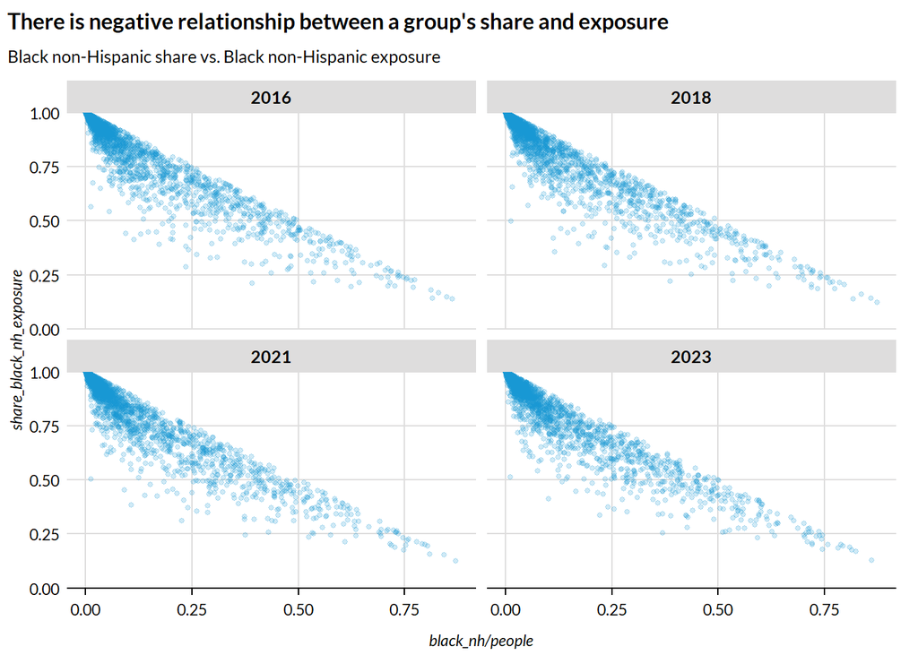

```r
county_data %>%
  ggplot(aes(black_nh / people, share_black_nh_exposure)) +
  geom_point(
    alpha = 0.2,
    size = 1
  ) +
  scale_y_continuous(
    expand = c(0, 0),
    limits = c(0, 1)
  ) +
  labs(
    title = "There is negative relationship between a group's share and exposure",
    subtitle = "Black non-Hispanic share vs. Black non-Hispanic exposure"
  ) +
  scatter_grid() +
  facet_wrap(. ~ year)
```

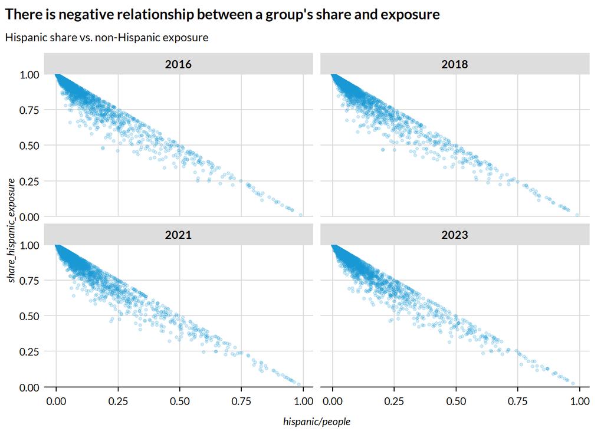

```r
county_data %>%
  ggplot(aes(hispanic / people, share_hispanic_exposure)) +
  geom_point(
    alpha = 0.2,
    size = 1
  ) +
  scale_y_continuous(
    expand = c(0, 0),
    limits = c(0, 1)
  ) +
  labs(
    title = "There is negative relationship between a group's share and exposure",
    subtitle = "Hispanic share vs. non-Hispanic exposure"
  ) +
  scatter_grid() +
  facet_wrap(. ~ year)
```

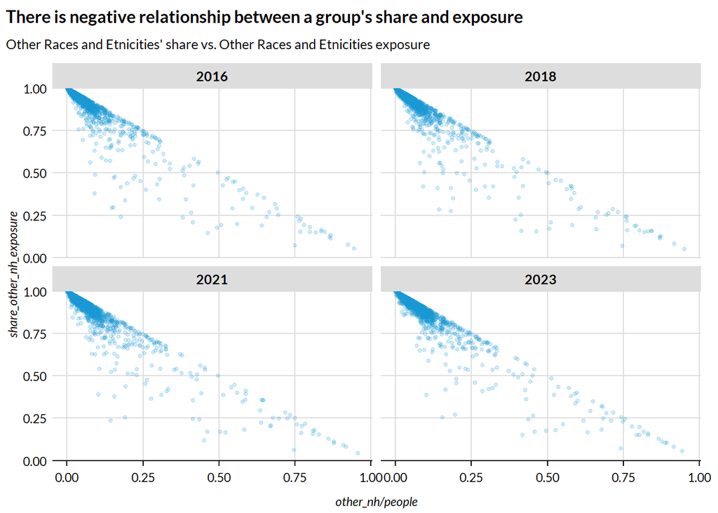

```r
county_data %>%
  ggplot(aes(other_nh / people, share_other_nh_exposure)) +
  geom_point(
    alpha = 0.2,
    size = 1
  ) +
  scale_y_continuous(
    expand = c(0, 0),
    limits = c(0, 1)
  ) +
  labs(
    title = "There is negative relationship between a group's share and exposure",
    subtitle = "Other Races and Etnicities' share vs. Other Races and Etnicities exposure"
  ) +
  scatter_grid() +
  facet_wrap(. ~ year)
```

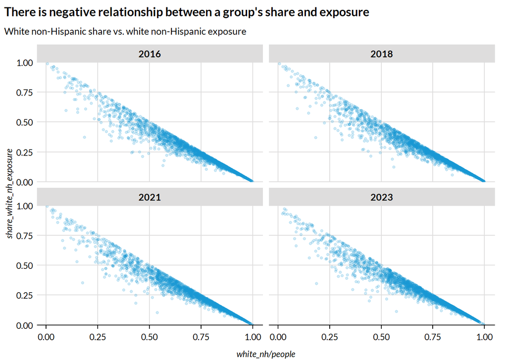

```r
county_data %>%
  ggplot(aes(white_nh / people, share_white_nh_exposure)) +
  geom_point(
    alpha = 0.2,
    size = 1
  ) +
  scale_y_continuous(
    expand = c(0, 0),
    limits = c(0, 1)
  ) +
  labs(
    title = "There is negative relationship between a group's share and exposure",
    subtitle = "White non-Hispanic share vs. white non-Hispanic exposure"
  ) +
  scatter_grid() +
  facet_wrap(. ~ year)
```

### 6. Add Data Quality Flags

First, we suppress exposure indices for groups in counties that have fewer than 30 individuals in that group. This excludes many observations that have very imprecise estimates.

```r
#' Suppress counties
#'
#' @param race The variable for the count in a race/ethnicity group
#' @param exposure The variable name for the exposure index
#' @param threshold The minimum size of the race group to report the exposure index
#'
#' @return
#'
suppress_county <- function(race, exposure, threshold) {
  exposure <- if_else(race <= threshold, as.numeric(NA), exposure)

  return(exposure)
}

county_data %>%
  summarize(
    share_black_nh_exposure = sum(is.na(share_black_nh_exposure)),
    share_hispanic_exposure = sum(is.na(share_hispanic_exposure)),
    share_other_nh_exposure = sum(is.na(share_other_nh_exposure)),
    share_white_nh_exposure = sum(is.na(share_white_nh_exposure)),
    .by = c(year)
  )
```

```
# A tibble: 4 × 5
   year share_black_nh_exposure share_hispanic_exposure share_other_nh_exposure
  <dbl>                   <int>                   <int>                   <int>
1  2016                     104                       8                      12
2  2018                      96                      14                      11
3  2021                      92                      15                       8
4  2023                      92                      15                       4
# ℹ 1 more variable: share_white_nh_exposure <int>
```

```r
county_data <- county_data %>%
  mutate(
    share_black_nh_exposure = suppress_county(black_nh, share_black_nh_exposure, threshold = 30),
    share_hispanic_exposure = suppress_county(hispanic, share_hispanic_exposure, threshold = 30),
    share_other_nh_exposure = suppress_county(other_nh, share_other_nh_exposure, threshold = 30),
    share_white_nh_exposure = suppress_county(white_nh, share_white_nh_exposure, threshold = 30)
  )

county_data %>%
  summarize(
    black_nh = sum(is.na(share_black_nh_exposure)),
    hispanic = sum(is.na(share_hispanic_exposure)),
    other_nh = sum(is.na(share_other_nh_exposure)),
    white_nh = sum(is.na(share_white_nh_exposure)),
    .by = c(year)
  )
```

```
# A tibble: 4 × 5
   year black_nh hispanic other_nh white_nh
  <dbl>    <int>    <int>    <int>    <int>
1  2016      474       98      111        1
2  2018      451       92      108        1
3  2021      453       91       65        2
4  2023      441       87       48        2
```

We need to add data quality flags with `1`, `2`, or `3`. The values are outlined in the [data standards](https://github.com/UI-Research/gates-mobility-metrics).

- `1` - If the county coefficient of variation for the count in the group is less than 0.2
- `2` - If the county coefficient of variation for the count in the group is less than 0.4
- `3` - If the county coefficient of variation for the count in the group exceeds 0.4 but the value is not `NA`
- `NA` - If the metric is missing

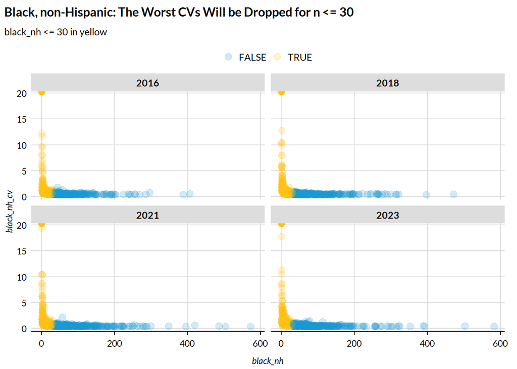

```r
county_data <- county_data %>%
  mutate(
    black_nh_cv = black_nh_se / black_nh,
    hispanic_cv = hispanic_se / hispanic,
    other_nh_cv = other_nh_se / other_nh,
    white_nh_cv = white_nh_se / white_nh
  )

county_data %>%
  filter(black_nh_cv >= 0.4) %>%
  ggplot(aes(black_nh, black_nh_cv, color = black_nh <= 30)) +
  geom_point(alpha = 0.2) +
  labs(
    title = "Black, non-Hispanic: The Worst CVs Will be Dropped for n <= 30",
    subtitle = "black_nh <= 30 in yellow"
  ) +
  scatter_grid() +
  facet_wrap(. ~ year)
```

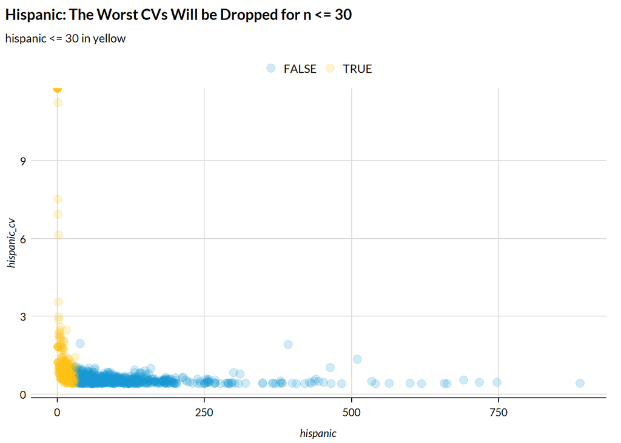

```r
county_data %>%
  filter(hispanic_cv >= 0.4) %>%
  ggplot(aes(hispanic, hispanic_cv, color = hispanic <= 30)) +
  geom_point(alpha = 0.2) +
  labs(
    title = "Hispanic: The Worst CVs Will be Dropped for n <= 30",
    subtitle = "hispanic <= 30 in yellow"
  ) +
  scatter_grid()
```

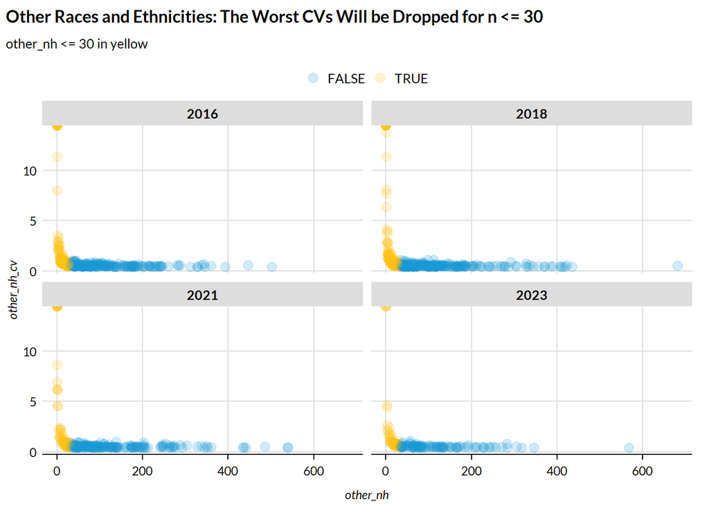

```r
county_data %>%
  filter(other_nh_cv >= 0.4) %>%
  ggplot(aes(other_nh, other_nh_cv, color = other_nh <= 30)) +
  geom_point(alpha = 0.2) +
  labs(
    title = "Other Races and Ethnicities: The Worst CVs Will be Dropped for n <= 30",
    subtitle = "other_nh <= 30 in yellow"
  ) +
  scatter_grid() +
  facet_wrap(. ~ year)
```

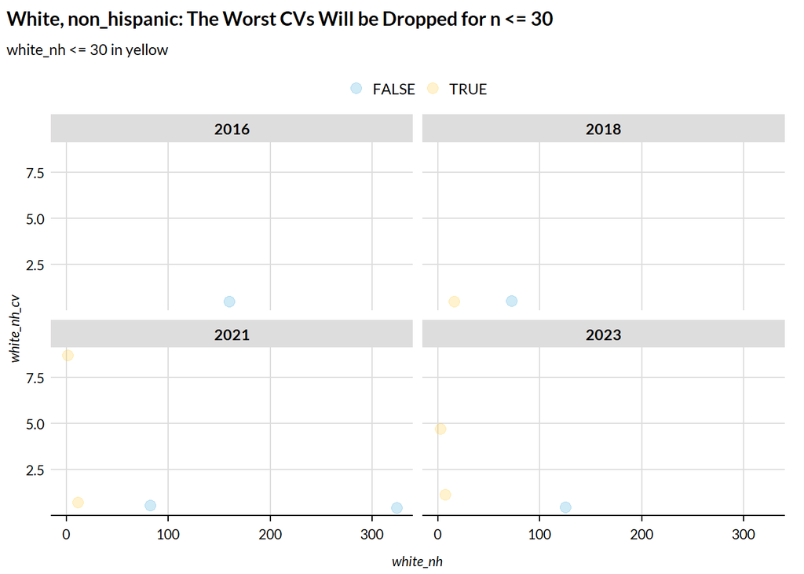

```r
county_data %>%
  filter(white_nh_cv >= 0.4) %>%
  ggplot(aes(white_nh, white_nh_cv, color = white_nh <= 30)) +
  geom_point(alpha = 0.2) +
  labs(
    title = "White, non_hispanic: The Worst CVs Will be Dropped for n <= 30",
    subtitle = "white_nh <= 30 in yellow"
  ) +
  scatter_grid() +
  facet_wrap(. ~ year)
```

```r
#' Assign a data quality flag
#'
#' @param race A vector of counts of a race/ethnicity group within a county
#' @param exposure A race/ethnicity exposure metric
#'
#' @return A numeric data quality flag
#'
set_quality <- function(cv, exposure) {
  quality <- case_when(
    cv < 0.2 ~ 1,
    cv < 0.4 ~ 2,
    cv >= 0.4 ~ 3
  )
  quality <- if_else(is.na(exposure), as.numeric(NA), quality)

  return(quality)
}

county_data <- county_data %>%
  mutate(
    share_black_nh_exposure_quality = set_quality(cv = black_nh_cv, exposure = share_black_nh_exposure),
    share_hispanic_exposure_quality = set_quality(cv = hispanic_cv, exposure = share_hispanic_exposure),
    share_other_nh_exposure_quality = set_quality(cv = other_nh_cv, exposure = share_other_nh_exposure),
    share_white_nh_exposure_quality = set_quality(cv = white_nh_cv, exposure = share_white_nh_exposure)
  )

count(county_data, share_black_nh_exposure_quality)
```

```
# A tibble: 4 × 2
  share_black_nh_exposure_quality     n
                            <dbl> <int>
1                               1  6728
2                               2  2691
3                               3  1333
4                              NA  1819
```

```r
count(county_data, share_hispanic_exposure_quality)
```

```
# A tibble: 4 × 2
  share_hispanic_exposure_quality     n
                            <dbl> <int>
1                               1  8727
2                               2  2802
3                               3   674
4                              NA   368
```

```r
count(county_data, share_other_nh_exposure_quality)
```

```
# A tibble: 4 × 2
  share_other_nh_exposure_quality     n
                            <dbl> <int>
1                               1  8052
2                               2  3460
3                               3   727
4                              NA   332
```

```r
count(county_data, share_white_nh_exposure_quality)
```

```
# A tibble: 4 × 2
  share_white_nh_exposure_quality     n
                            <dbl> <int>
1                               1 12517
2                               2    43
3                               3     5
4                              NA     6
```

Most of the counties with missing values are very small.

```r
missing <- county_data %>%
  filter(
    is.na(share_black_nh_exposure) |
      is.na(share_hispanic_exposure) |
      is.na(share_other_nh_exposure) |
      is.na(share_white_nh_exposure)
  )

max(missing$people)
```

```
[1] 65568
```

```r
max(missing$tracts)
```

```
[1] 17
```

We’ve produced estimates for every county in every analysis year:

```r
## our universe of counties, by year
county_targets = read_csv(here("geographic-crosswalks", "data", "county-populations.csv"))

## the number of calculated counties should be the same as the number of target counties
stopifnot(
  county_targets %>%
    count(year) %>%
    filter(year %in% years) %>%
    rename(target_counts = n) %>%
  left_join(
    county_data %>%
    count(year) %>%
      rename(analysis_counts = n)) %>%
  filter(target_counts != analysis_counts) %>%
    nrow == 0)
```

### 7. Save the Data

```r
county_data %>%
  select(
    year,
    state,
    county,
    share_black_nh_exposure,
    share_black_nh_exposure_quality,
    share_hispanic_exposure,
    share_hispanic_exposure_quality,
    share_other_nh_exposure,
    share_other_nh_exposure_quality,
    share_white_nh_exposure,
    share_white_nh_exposure_quality
  ) %>%
  write_csv(here::here("06_neighborhoods", "race-ethnicity-exposure", "race-ethnicity-exposure-county.csv"))
```

## Testing

```r
final_data <- read_csv(here::here("06_neighborhoods", "race-ethnicity-exposure",
                                  "final", "race-ethnicity-exposure-county.csv"),
                       show_col_types = FALSE)

evaluate_final_data(
  exp_form_path = "10a_final-evaluation/evaluation_form_share_race_exposure_overall_county.csv",
  data = final_data, geography = "county",
  subgroups = FALSE, confidence_intervals = FALSE
)
```

```
[1] "This data passes all tests!"
```